# SquareWave

## DFT of Square Waves / Sawtooth Waves

### [Chris Tralie](http://www.ctralie.com)

The purpose of this notebook is to create an animation of a time shifting square wave. A square wave can be written as

#### $y(t) = sgn(\sin(2 \pi f t))$

where

#### $ sgn(x) = \left\{ \begin{array}{cc} 1 & x > 0 \\ 0 & x = 0 \\ -1 & x < 0 \end{array} \right\} $

Its fourier series is

### $y(t) = \frac{4}{\pi} \sum_{k = 0}^{\infty} \frac{\sin(2 \pi (2k+1)f t)}{2k+1} $

If we shift the signal by an amount $s$ and evalate $y(t - s)$, then this is

### $y(t-s) = \frac{4}{\pi} \sum_{k = 0}^{\infty} \frac{\sin(2 \pi (2k+1)f (t-s))}{2k+1} = \frac{4}{\pi} \sum_{k = 0}^{\infty} \frac{\sin(2 \pi (2k+1)f t - 2 \pi (2k+1)f s))}{2k+1} $

We notice that the phase here is

$ - 2 \pi (2k+1)f s $

So for the same shift in time, the higher frequency indices $k$ get a larger phase shift.

### Time Scaling

```python
import numpy as np
import matplotlib.pyplot as plt
```

```python
def get_dft(x):
    """
    Return the non-redundant real/imaginary components
    of the DFT, expressed as amplitudes of sines/cosines
    involved

    Parameters
    ----------
    x: ndarray(N)
        A signal

    Returns
    -------
    cos_sum: ndarray(ceil(N/2)), sin_sums(ndarray(ceil(N/2)))
        DFT cosine/sine amplitudes
    """
    N = len(x)
    t = np.linspace(0, 1, N+1)[0:N]
    n_freqs = int(np.ceil(N/2))
    f = np.fft.fft(x)
    cos_sums = np.real(f)[0:n_freqs]/(N/2)
    sin_sums = -np.imag(f)[0:n_freqs]/(N/2)
    return cos_sums, sin_sums
```

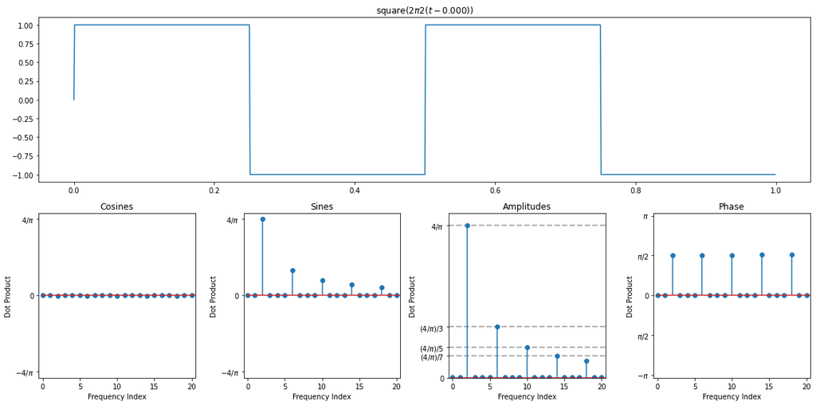

```python
"""
Create a frame of one period of a square wave
while plotting its cosine/sine components
of the discrete Fourier Transform, as well as
the associated amplitudes/phases

Parameters
----------
N: int

max_freq_index: int
    Maximum frequency index to show in the plots
f: int

"""
N = 1000 # Number of samples to take in the square wave
max_freq_index = 20 # Maximum frequency index to show in the plots
f = 2 # Frequency of the sinusoid, in units of cycles per interval N

t = np.linspace(0, 1, N+1)[0:N]
plt.figure(figsize=(16, 8))

shift = 0

x = np.sign(np.sin(2*np.pi*f*(t-shift)))
c, s = get_dft(x)
amps = np.sqrt(c**2+s**2)
phases = np.arctan2(s, c)
plt.clf()
plt.subplot2grid((2, 4), (0, 0), rowspan=1, colspan=4)
plt.plot(t, x)
plt.ylim([-1.1, 1.1])
plt.title("square$(2 \pi {} (t - {:.3f}))$".format(f, shift))
plt.subplot(245)
plt.stem(c[0:max_freq_index+2], use_line_collection=True)
plt.xlabel("Frequency Index")
plt.ylabel("Dot Product")
plt.title("Cosines")
plt.ylim([-4/np.pi-0.1, 4/np.pi+0.1])
plt.yticks([-4/np.pi, 0, 4/np.pi], ["$-4/\\pi$", "0", "$4/\\pi$"])
plt.xlim([-0.5, max_freq_index+0.5])
plt.subplot(246)
plt.stem(s[0:max_freq_index+2], use_line_collection=True)
plt.xlabel("Frequency Index")
plt.ylabel("Dot Product")
plt.title("Sines")
plt.ylim([-4/np.pi-0.1, 4/np.pi+0.1])
plt.yticks([-4/np.pi, 0, 4/np.pi], ["$-4/\\pi$", "0", "$4/\\pi$"])
plt.xlim([-0.5, max_freq_index+0.5])
plt.subplot(247)
plt.stem(amps[0:max_freq_index+2], use_line_collection=True)
plt.xlabel("Frequency Index")
plt.ylabel("Dot Product")
plt.title("Amplitudes")
plt.ylim([0, 4/np.pi+0.1])
plt.yticks([0, 4/np.pi/3, 4/np.pi/5, 4/np.pi/7, 4/np.pi], ["0", "$(4/\\pi)/3$", "$(4/\\pi)/5$", "$(4/\\pi)/7$", "$4/\\pi$"])
plt.xlim([-0.5, max_freq_index+0.5])
plt.grid(linestyle='--', linewidth=2, axis='y')
plt.subplot(248)
plt.stem((amps[0:max_freq_index+2]>1e-3)*phases[0:max_freq_index+2], use_line_collection=True)
plt.xlim([-0.5, max_freq_index+0.5])
plt.ylim([-np.pi-0.1, np.pi+0.1])
plt.yticks([-np.pi, -np.pi/2, 0, np.pi/2, np.pi], ["$-\\pi$", "$\\pi/2$", "0", "$\\pi/2$", "$\\pi$"])
plt.xlabel("Frequency Index")
plt.ylabel("Phase (Radians)")
plt.title("Phase")
plt.tight_layout()
```

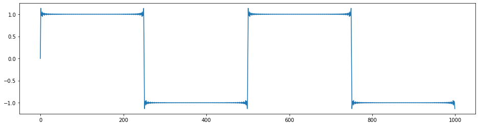

```python
N = 1000
t = np.linspace(0, 1, N+1)[0:N]
y = np.zeros(N)
for k in range(100):
    y += (4/np.pi)*np.sin(2*np.pi*2*(2*k+1)*t)/(2*k+1)
plt.figure(figsize=(16, 4))
plt.plot(y)
```

[figure not shown]

The higher frequencies have much larger phase shifts for the same shift in time since

$ \cos(2 \pi f (t - s)) = \cos(2 \pi f t - 2 \pi f s)) $

implies that the phase $\phi = - 2 \pi f s$ for each frequency $f$, which is larger for a larger $f$

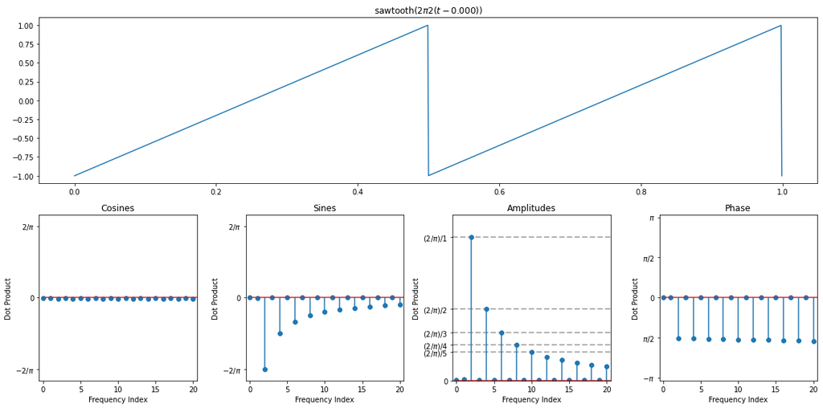

```python
N = 1000 # Number of samples to take in the square wave
plot_lim = 20 # Maximum frequency index to show in the plots
f = 2 # Frequency of the sinusoid, in units of cycles per interval N

t = np.linspace(0, 1, N+1)[0:N]
plt.figure(figsize=(16, 8))

shift = 0
x = 2*np.mod(np.linspace(-shift, f-shift, N), 1)-1
c, s = get_dft(x)
amps = np.sqrt(c**2+s**2)
phases = np.arctan2(s, c)
plt.clf()
plt.subplot2grid((2, 4), (0, 0), rowspan=1, colspan=4)
plt.plot(t, x)
plt.ylim([-1.1, 1.1])
plt.title("sawtooth$(2 \pi {} (t - {:.3f}))$".format(f, shift/f))
plt.subplot(245)
plt.stem(c, use_line_collection=True)
plt.xlabel("Frequency Index")
plt.ylabel("Dot Product")
plt.title("Cosines")
plt.ylim([-2/np.pi-0.1, 2/np.pi+0.1])
plt.yticks([-2/np.pi, 0, 2/np.pi], ["$-2/\\pi$", "0", "$2/\\pi$"])
plt.xlim([-0.5, plot_lim+0.5])
plt.subplot(246)
plt.stem(s, use_line_collection=True)
plt.xlabel("Frequency Index")
plt.ylabel("Dot Product")
plt.title("Sines")
plt.ylim([-2/np.pi-0.1, 2/np.pi+0.1])
plt.yticks([-2/np.pi, 0, 2/np.pi], ["$-2/\\pi$", "0", "$2/\\pi$"])
plt.xlim([-0.5, plot_lim+0.5])
plt.subplot(247)
plt.stem(amps, use_line_collection=True)
plt.xlabel("Frequency Index")
plt.ylabel("Dot Product")
plt.title("Amplitudes")
plt.ylim([0, 2/np.pi+0.1])
plt.yticks([0] + [2/np.pi/k for k in range(1, 6)], ["0"]+["$(2/\\pi)/{}$".format(k) for k in range(1, 6)])
plt.xlim([-0.5, plot_lim+0.5])
plt.grid(linestyle='--', linewidth=2, axis='y')
plt.subplot(248)
plt.stem((amps>1e-2)*phases, use_line_collection=True)
plt.ylim([-np.pi-0.1, np.pi+0.1])
plt.yticks([-np.pi, -np.pi/2, 0, np.pi/2, np.pi], ["$-\\pi$", "$\\pi/2$", "0", "$\\pi/2$", "$\\pi$"])
plt.xlim([-0.5, plot_lim+0.5])
plt.xlabel("Frequency Index")
plt.ylabel("Phase (Radians)")
plt.title("Phase")
plt.tight_layout()
```

Just as with the square wave, we can approximate the sawtooth wave by reverse engineering from its DFT representation

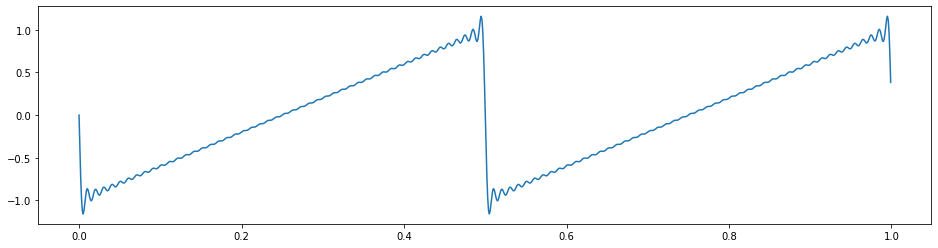

```python
N = 1000
t = np.linspace(0, 1, N+1)[0:N]
y = np.zeros(N)
for k in range(1, 50):
    y += -(2/np.pi)*np.sin(2*np.pi*2*k*t)/k
plt.figure(figsize=(16, 4))
plt.plot(t, y)
```

[figure not shown]